# 1주차 패키지 문제

2019313106 홍현경

2021년 3월 10일

# Chapter 1. 전처리

## [문제 0] 기본 세팅

- 패키지를 plyr, tidyverse, data.table 순으로 불러오기

```r
library(plyr)
library(tidyverse)
library(data.table)
```

- setwd로 “data.csv”가 있는 폴더로 경로 설정

```r
setwd("C:/Users/hyung/Desktop/P-Sat/week1")
```

- fread 이용하여 “data.csv” 불러오기

```r
data <- fread("data.csv")
```

## [문제 1] 데이터 확인하기

- str 이용하여 데이터의 구성 살펴보기

```r
data %>% str
```

```
## Classes 'data.table' and 'data.frame':   5165 obs. of  8 variables:
##  $ patient_id    : 'integer64' num  4.94e-315 4.94e-315 4.94e-315 4.94e-315 4.94e-315 ...
##  $ sex           : chr  "male" "male" "male" "male" ...
##  $ age           : chr  "50s" "30s" "50s" "20s" ...
##  $ country       : chr  "Korea" "Korea" "Korea" "Korea" ...
##  $ province      : chr  "서울" "서울" "서울" "서울" ...
##  $ city          : chr  "강서구" "중랑구" "종로구" "마포구" ...
##  $ confirmed_date: IDate, format: "2020-01-23" "2020-01-30" ...
##  $ state         : chr  "released" "released" "released" "released" ...
##  - attr(*, ".internal.selfref")=<externalptr>
```

- 각 열의 NA 개수 확인

```r
data %>% is.na %>% colSums
```

```
##     patient_id            sex            age        country       province
##              0              0              0              0              0
##           city confirmed_date          state
##              0              3              0
```

- 각 열의 unique 값 확인
- 리스트 요소가 너무 많아 head를 통해 각 리스트 요소의 일부만 출력

```r
data %>% lapply(unique) %>% lapply(head)
```

```
## $patient_id
## [1] 4.940656e-315 4.940656e-315 4.940656e-315 4.940656e-315 4.940656e-315
## [6] 4.940656e-315
##
## $sex
## [1] "male"   "female" ""
##
## $age
## [1] "50s" "30s" "20s" "60s" "80s" "70s"
##
## $country
## [1] "Korea"         "China"         "United States" "France"
## [5] "Thailand"      "Canada"
##
## $province
## [1] "서울" "부산" "대구" "광주" "인천" "대전"
##
## $city
## [1] "강서구" "중랑구" "종로구" "마포구" "성북구" "기타"
##
## $confirmed_date
## [1] "2020-01-23" "2020-01-30" "2020-01-31" "2020-02-02" "2020-02-05"
## [6] "2020-02-06"
##
## $state
## [1] "released" "deceased" "isolated"
```

- 각 열의 unique 값 개수 확인

```r
data %>% lapply(unique) %>% sapply(length)
```

```
##     patient_id            sex            age        country       province
##           5164              3             12             16             17
##           city confirmed_date          state
##            163            149              3
```

## [문제 2-1]

- NA가 있는 행 삭제

```r
data <- data %>% filter(!is.na(confirmed_date))
```

## [문제 2-2]

- 각 열별로 빈 문자열이 존재하는지 확인

```r
which(data$patient_id == "") %>% length
```

```
## [1] 0
```

```r
which(data$sex == "") %>% length
```

```
## [1] 1122
```

```r
which(data$age == "") %>% length
```

```
## [1] 1380
```

```r
which(data$country == "") %>% length
```

```
## [1] 0
```

```r
which(data$province == "") %>% length
```

```
## [1] 0
```

```r
which(data$city == "") %>% length
```

```
## [1] 94
```

```r
which(data$confirmed_date == "") %>% length
```

```
## [1] 0
```

```r
which(data$state == "") %>% length
```

```
## [1] 0
```

- 위 코드 실행 결과, sex, age, city 열(변수)에서 빈 문자열이 확인됨
- which 실행 결과 행 인덱스가 반환되므로, sex, age, city에서 나온 각 행 인덱스를 하나의 벡터로 합친 후, 행 인덱스의 중복을 제거하기 위해 unique 처리

```r
blank_idx <- unique(c(which(data$sex == ""), which(data$age == ""), which(data$city == "")))
```

- 빈 문자열이 존재하는 행의 인덱스를 blank_idx 변수에 저장하였음
- 이 blank_idx를 이용하여 빈 문자열이 존재하는 행 제거 및 data 업데이트

```r
data <- data[-blank_idx,]
```

- 각 열의 NA 개수 재확인

```r
data %>% is.na %>% colSums
```

```
##     patient_id            sex            age        country       province
##              0              0              0              0              0
##           city confirmed_date          state
##              0              0              0
```

- 각 열의 unique 값 재확인
- 리스트 요소가 너무 많아 head를 통해 각 리스트 요소의 일부만 출력

```r
data %>% lapply(unique) %>% lapply(head)
```

```
## $patient_id
## [1] 4.940656e-315 4.940656e-315 4.940656e-315 4.940656e-315 4.940656e-315
## [6] 4.940656e-315
##
## $sex
## [1] "male"   "female"
##
## $age
## [1] "50s" "30s" "20s" "60s" "80s" "70s"
##
## $country
## [1] "Korea"         "China"         "United States" "France"
## [5] "Thailand"      "Canada"
##
## $province
## [1] "서울"   "부산"   "대구"   "인천"   "대전"   "경기도"
##
## $city
## [1] "강서구" "중랑구" "종로구" "마포구" "성북구" "기타"
##
## $confirmed_date
## [1] "2020-01-23" "2020-01-30" "2020-01-31" "2020-02-02" "2020-02-05"
## [6] "2020-02-06"
##
## $state
## [1] "released" "deceased" "isolated"
```

- 각 열의 unique 값 개수 재확인

```r
data %>% lapply(unique) %>% sapply(length)
```

```
##     patient_id            sex            age        country       province
##           3689              2             11             15             16
##           city confirmed_date          state
##            158            145              3
```

## [문제 3]

```r
data <- data %>% filter(country == "Korea")
```

- 필터링 후 country 변수의 값이 “Korea”가 아닌 것이 있는지 확인

```r
which(data$country != "Korea")
```

```
## integer(0)
```

## [문제 4]

- province 변수 내 “서울, 부산, 대구, 인천, 대전, 세종, 울산, 제주도”의 값 변경

```r
data$province <- data$province %>% revalue(c("서울"="서울특별시", "부산"="부산광역시", "대구"="대구광역시", "인천"="인천광역시", "대전"="대전광역시", "세종"="세종특별자치시", "울산"="울산광역시", "제주도"="제주특별자치도"))
```

## [문제 5]

- confirmed_date를 날짜 자료형(Date)으로 변환

```r
data$confirmed_date <- data$confirmed_date %>%  as.Date
```

## [문제 6]

- confirmed_date 별 확진자 수에 대한 파생 변수 생성

```r
data <- data %>% group_by(confirmed_date) %>% mutate(confirmed_number = n())
```

## [문제 7]

- confirmed_date의 주말 여부에 대한 파생 변수 생성

```r
data$wday <- weekdays(data$confirmed_date) %>%
  revalue(c("월요일"= "주중", "화요일"= "주중", "수요일" = "주중", "목요일"= "주중", "금요일" = "주중", "토요일"="주말", "일요일"="주말"))
```

[output not shown]

## [문제 8]

- 나이대 별 일별 확진자 수에 대한 summary 확인
- 위에서 구한 confirmed_number의 경우 나이대를 고려하지 않은 일별 전체 확진자 수 이므로 data를 새롭게 그룹화

```r
data_extracted <- data %>% group_by(age, confirmed_date) %>% summarise(count = n())
tapply(data_extracted$count, data_extracted$age, summary)
```

```
## $`0s`
##    Min. 1st Qu.  Median    Mean 3rd Qu.    Max.
##   1.000   1.000   1.000   1.488   2.000   3.000
##
## $`100s`
##    Min. 1st Qu.  Median    Mean 3rd Qu.    Max.
##       1       1       1       1       1       1
##
## $`10s`
##    Min. 1st Qu.  Median    Mean 3rd Qu.    Max.
##   1.000   1.000   2.000   2.276   3.000   8.000
##
## $`20s`
##    Min. 1st Qu.  Median    Mean 3rd Qu.    Max.
##   1.000   1.000   3.500   7.526  11.000  43.000
##
## $`30s`
##    Min. 1st Qu.  Median    Mean 3rd Qu.    Max.
##   1.000   2.000   3.000   5.051   8.000  17.000
##
## $`40s`
##    Min. 1st Qu.  Median    Mean 3rd Qu.    Max.
##   1.000   1.000   2.000   4.931   6.000  33.000
##
## $`50s`
##    Min. 1st Qu.  Median    Mean 3rd Qu.    Max.
##   1.000   1.000   3.000   6.112   9.000  31.000
##
## $`60s`
##    Min. 1st Qu.  Median    Mean 3rd Qu.    Max.
##   1.000   1.000   3.000   4.722   7.000  22.000
##
## $`70s`
##    Min. 1st Qu.  Median    Mean 3rd Qu.    Max.
##   1.000   1.000   2.000   2.908   3.250  13.000
##
## $`80s`
##    Min. 1st Qu.  Median    Mean 3rd Qu.    Max.
##   1.000   1.000   2.000   3.019   3.750  24.000
##
## $`90s`
##    Min. 1st Qu.  Median    Mean 3rd Qu.    Max.
##   1.000   1.000   1.000   2.286   2.000  16.000
```

# Chapter 2. 시각화

## [문제 1-1] Line Plot

- Line plotting시 최대 확진자 수 관련 정보를 함께 표시하기 위해 확진자 수가 가장 많은 날짜를 확인

```r
max_num <- max(data$confirmed_number); max_num
```

```
## [1] 143
```

```r
max_date <- data$confirmed_date[which(data$confirmed_number==max_num)] %>% unique; max_date
```

```
## [1] "2020-03-05"
```

- ggplot2를 이용하여 line plotting 시행

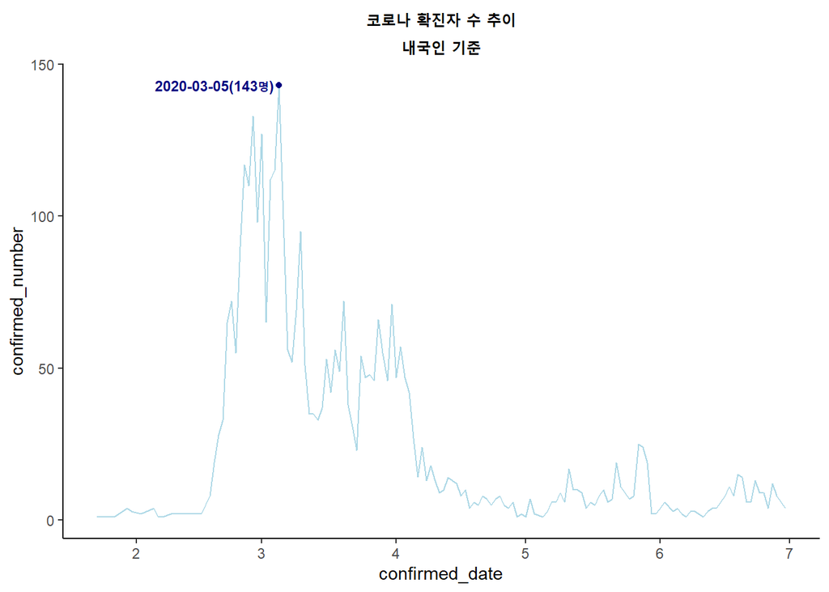

```r
data %>% ggplot() +
  geom_line(aes(x=confirmed_date, y=confirmed_number), color = "lightblue") +
  geom_point(aes( x=max_date,y=max_num), col="navy")+
  annotate("text", x=max_date-15,y=max_num,
           label="2020-03-05(143명)", col="navy", fontface="bold", size=3)+
  theme_classic() +
  theme(plot.title=element_text(face="bold", size=12, hjust=0.5),
      plot.subtitle=element_text(face="bold", size=12, hjust=0.5)) +
  ggtitle("코로나 확진자 수 추이", subtitle="내국인 기준")
```

## [문제 1-2] Line Plot - Faceting 이용

- province별 확진자 수 추이 그래프
- province별로 구분해야 하므로 faceting 이용, province별로 색깔 다르게 표시

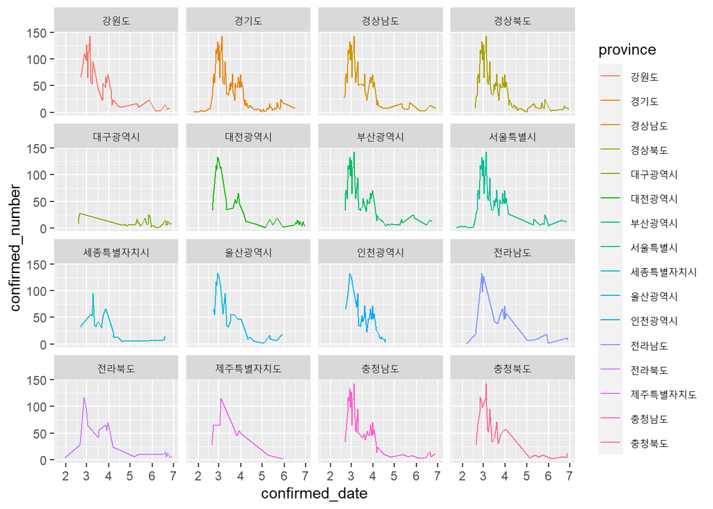

```r
data %>% ggplot(aes(x=confirmed_date, y=confirmed_number, color=province))+
  geom_line()+
  facet_wrap(facets=vars(province))
```

## [문제 2] Bar Plot

- 지역별 확진자 수를 state 그룹 별로 나누어 Bar Plot 그리기
- data를 해당 문제에서 필요한 변수들인 province, state를 기준으로 그룹화 후 province, state별 확진자 수를 count 변수로 추가
- 세 변수가 포함된 데이터를 province_data로 저장

```r
province_data <- data %>% group_by(province, state) %>% summarise(count=n())
province_data
```

```
## # A tibble: 37 x 3
## # Groups:   province [16]
##    province state    count
##    <chr>    <chr>    <int>
##  1 강원도   deceased     3
##  2 강원도   isolated    13
##  3 강원도   released    43
##  4 경기도   isolated   768
##  5 경기도   released    57
##  6 경상남도 isolated     6
##  7 경상남도 released   123
##  8 경상북도 deceased    42
##  9 경상북도 isolated   130
## 10 경상북도 released  1068
## # ... with 27 more rows
```

- province_data를 bar plot으로 나타내기
- count를 기준으로 하여 province변수를 decending order로 나타냄

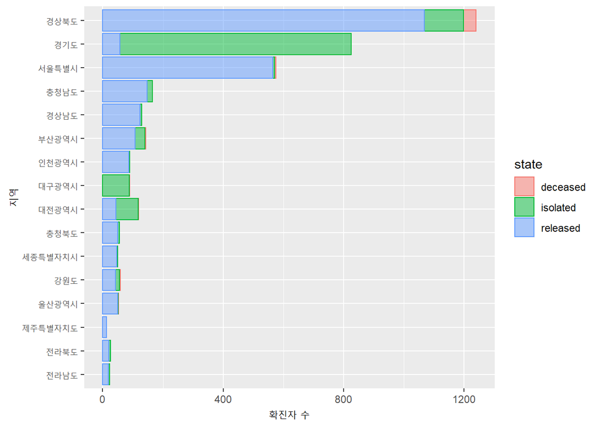

```r
province_data %>% ggplot(aes(x=reorder(province, count), y=count, color=state, fill=state))+
  geom_bar(stat="identity", alpha=0.5)+
  labs(x="지역", y="확진자 수")+
  coord_flip()
```

## [문제 3-1] Box Plot

- 나이대별 일별 확진자 수 box plot 그리기
- chapter 1의 문제 8에서 사용한 data_extracted 이용

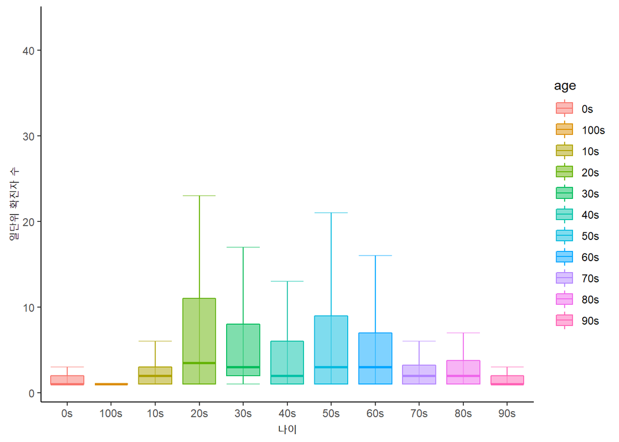

```r
data_extracted %>%
  ggplot(aes(x=age, y=count, fill=age, color=age))+
  geom_boxplot(outlier.shape = NA, alpha=0.5)+
  stat_boxplot(geom="errorbar", alpha=0.5)+
  theme_classic()+
  labs(x="나이", y="일단위 확진자 수")
```

- 나이대별 일별 확진자 수에 대한 일원분산분석(one-way ANOVA) 실시
- 나이대별 확진자 수에 대한 일원분산분석

```r
oneway_age <- aov(count ~ age, data=data_extracted)
summary(oneway_age)
```

```
##              Df Sum Sq Mean Sq F value   Pr(>F)
## age          10   2575  257.48   8.823 8.19e-14 ***
## Residuals   780  22764   29.18
## ---
## Signif. codes:  0 '***' 0.001 '**' 0.01 '*' 0.05 '.' 0.1 ' ' 1
```

[해석] 확진자 수는 나이대에 유의한 영향을 받고 있다.

```r
oneway_date <- aov(count ~ confirmed_date, data=data_extracted)
summary(oneway_date)
```

```
##                 Df Sum Sq Mean Sq F value Pr(>F)
## confirmed_date   1   4019    4019   148.8 <2e-16 ***
## Residuals      789  21319      27
## ---
## Signif. codes:  0 '***' 0.001 '**' 0.01 '*' 0.05 '.' 0.1 ' ' 1
```

[해석] 확진자 수는 확진 날짜에 유의한 영향을 받고 있다.

# Chapter 3. 모델링_회귀분석

## [문제 1] 상관계수 plot 생성 및 해석

- 패키지 불러오기

```r
library(MASS)
# library(tidyverse)
library(corrplot)
library(caret)
library(MLmetrics)
```

- 사용할 데이터 확인 후 data에 저장

```r
head(Boston)
```

```
##      crim zn indus chas   nox    rm  age    dis rad tax ptratio  black lstat
## 1 0.00632 18  2.31    0 0.538 6.575 65.2 4.0900   1 296    15.3 396.90  4.98
## 2 0.02731  0  7.07    0 0.469 6.421 78.9 4.9671   2 242    17.8 396.90  9.14
## 3 0.02729  0  7.07    0 0.469 7.185 61.1 4.9671   2 242    17.8 392.83  4.03
## 4 0.03237  0  2.18    0 0.458 6.998 45.8 6.0622   3 222    18.7 394.63  2.94
## 5 0.06905  0  2.18    0 0.458 7.147 54.2 6.0622   3 222    18.7 396.90  5.33
## 6 0.02985  0  2.18    0 0.458 6.430 58.7 6.0622   3 222    18.7 394.12  5.21
##   medv
## 1 24.0
## 2 21.6
## 3 34.7
## 4 33.4
## 5 36.2
## 6 28.7
```

```r
data <- Boston
```

- data의 상관계수를 구한 후 이를 data_cor에 저장
- 구한 data_cor을 바탕으로 상관계수 plot 생성
- 상관계수 plot 내부의 글씨가 겹치는 문제를 해결하기 위해 글씨 크기 조정
- 상관계수 plot은 symmetric이므로 plot의 윗부분만 출력

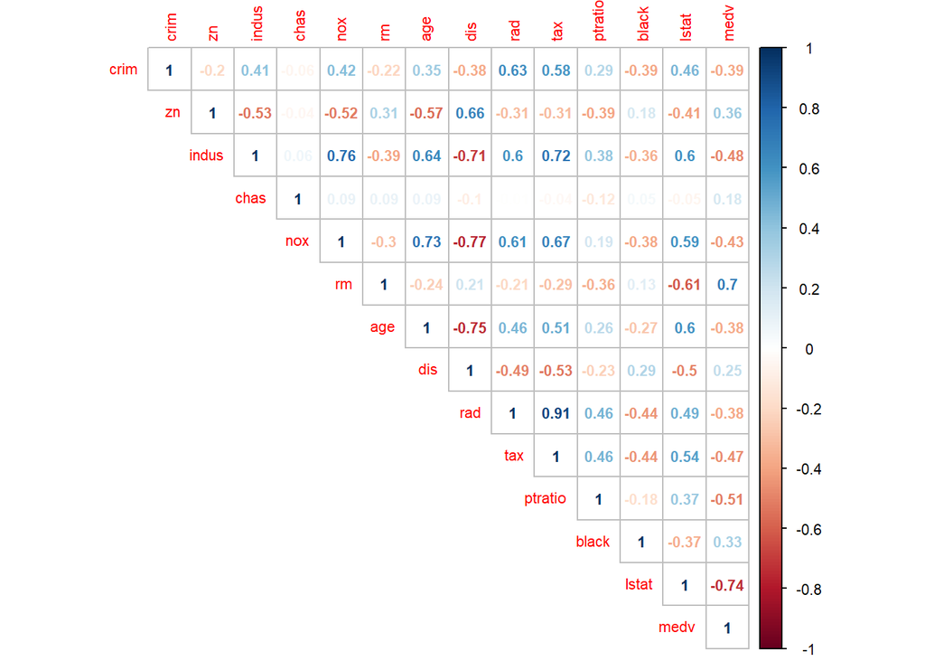

```r
data_cor <- data %>% cor
data_cor %>% corrplot(method="number", type="upper",
         tl.cex=0.7, cl.cex=0.7, number.cex=0.7)
```

[해석] 강한 양의 상관관계를 보이는 변수들: (nox,indus), (nox,age), (tax,indus), (tax,rad), (medv,rm) / 강한 음의 상관관계를 보이는 변수들: (dis,indus), (dis,nox), (dis,age), (medv,lstat)

## [문제 2] 종속변수 medv와 그 이외 변수간의 관계 파악

- scatterplot 및 회귀 추세선 그리기

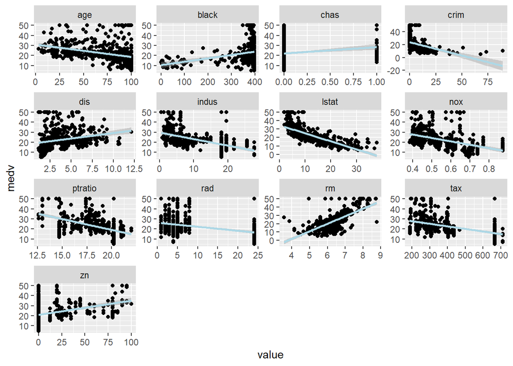

```r
data %>%
  gather(key="variable", value="value",-medv) %>%
  ggplot(aes(x=value, y=medv))+
  geom_point()+
  geom_smooth(method="lm", color="lightblue")+
  facet_wrap(~ variable, scales="free")
```

## [문제 3-1] 데이터를 train/test(7:3)으로 나누기

- caret 패키지의 createDataPartition 함수를 이용하여 train/test 데이터를 분리

```r
set.seed(1234)

train_idx <- createDataPartition(data$medv, times=1, p=0.7, list=FALSE)
train_data <- data[train_idx,]
test_data <- data[-train_idx,]
```

## [문제 3-2]

- train 데이터를 이용하여 medv를 종속변수로 하고 나머지를 모두 독립 변수로 하는 회귀 모형 생성

```r
fit <- lm(medv~., data=train_data)
summary(fit)
```

```
##
## Call:
## lm(formula = medv ~ ., data = train_data)
##
## Residuals:
##      Min       1Q   Median       3Q      Max
## -11.3323  -2.8734  -0.6592   1.9638  23.5680
##
## Coefficients:
##               Estimate Std. Error t value Pr(>|t|)
## (Intercept)  39.141877   6.297934   6.215 1.49e-09 ***
## crim         -0.134206   0.038868  -3.453 0.000624 ***
## zn            0.050246   0.017306   2.903 0.003931 **
## indus        -0.007431   0.078241  -0.095 0.924393
## chas          2.940348   1.104224   2.663 0.008115 **
## nox         -17.620358   4.847780  -3.635 0.000321 ***
## rm            3.441546   0.509100   6.760 5.97e-11 ***
## age           0.015060   0.016439   0.916 0.360236
## dis          -1.482356   0.240633  -6.160 2.04e-09 ***
## rad           0.397221   0.083820   4.739 3.16e-06 ***
## tax          -0.013384   0.004781  -2.800 0.005406 **
## ptratio      -0.973610   0.161098  -6.044 3.94e-09 ***
## black         0.009445   0.003302   2.860 0.004494 **
## lstat        -0.593385   0.059098 -10.041  < 2e-16 ***
## ---
## Signif. codes:  0 '***' 0.001 '**' 0.01 '*' 0.05 '.' 0.1 ' ' 1
##
## Residual standard error: 4.941 on 342 degrees of freedom
## Multiple R-squared:  0.735,  Adjusted R-squared:  0.7249
## F-statistic: 72.97 on 13 and 342 DF,  p-value: < 2.2e-16
```

- 회귀 모형의 결과 해석
1. F-test에서의 p-value가 0.05보다 작기 때문에, 독립 변수의 coefficients중 적어도 하나는 0이 아님을 알 수 있다. 즉, 종속변수와 독립변수 전체 set은 관련이 있음을 알 수 있다.
2. 한 독립변수의 예측된 coefficients값은 다른 독립 변수들이 고정되어 있을 때, 해당 독립변수가 한 단위 변화하면 종속변수가 얼마나 변화하는지를 나타낸다. 또한, t-test에서의 p-value가 0.05보다 작은 경우 해당 독립변수가 종속변수에 유의미한 영향을 미치고 있음을 알 수 있다. 위의 모델에서는 indus 및 age변수를 제외한 나머지 독립변수들이 종속변수에 유의미한 영향을 미치고 있음을 알 수 있다.
3. Adjusted R-squared의 값이 0.7249이므로 회귀모형의 독립변수들이 종속변수 variation의 72.49%를 설명할 수 있음을 알 수 있다. 따라서 이 회귀모형은 변수간의 관계를 어느 정도 잘 표현하고 있다고 볼 수 있다.
- test에 대한 RMSE

```r
prediction <- predict(fit, test_data)
RMSE(test_data$medv, prediction)
```

```
## [1] 4.423034
```

## [문제 3-3]

- 모델의 RMSE를 낮출 수 있는 방법
- 경사 하강법을 이용하여 오차를 줄여나간다.

## [문제 4] 회귀모형의 계수 시각화

- ggplot사용을 위해 fit$coefficients를 dataframe으로 변환하고 시작
- 데이터 시각화를 용이하게 하기 위해 fit$coefficients를 소숫점 둘째 자리까지 반올림하여 나타냄
- fit_coefficients에는 라벨이 붙어있고, 데이터 시각화 시 이 라벨과 fit_coefficients 값을 이용할 것이므로 label과 fit_coefficients를 하나의 dataframe으로 만든 후 dataframe에 불필요하게 남아있는 label을 제거

```r
fit_coefficients <- fit$coefficients %>%
  round(digits=2)

fit_df <- data.frame(labels=labels(fit_coefficients), fit_coefficients)
rownames(fit_df) <- NULL

fit_df # 데이터 확인
```

```
##         labels fit_coefficients
## 1  (Intercept)            39.14
## 2         crim            -0.13
## 3           zn             0.05
## 4        indus            -0.01
## 5         chas             2.94
## 6          nox           -17.62
## 7           rm             3.44
## 8          age             0.02
## 9          dis            -1.48
## 10         rad             0.40
## 11         tax            -0.01
## 12     ptratio            -0.97
## 13       black             0.01
## 14       lstat            -0.59
```

- 데이터 시각화 진행

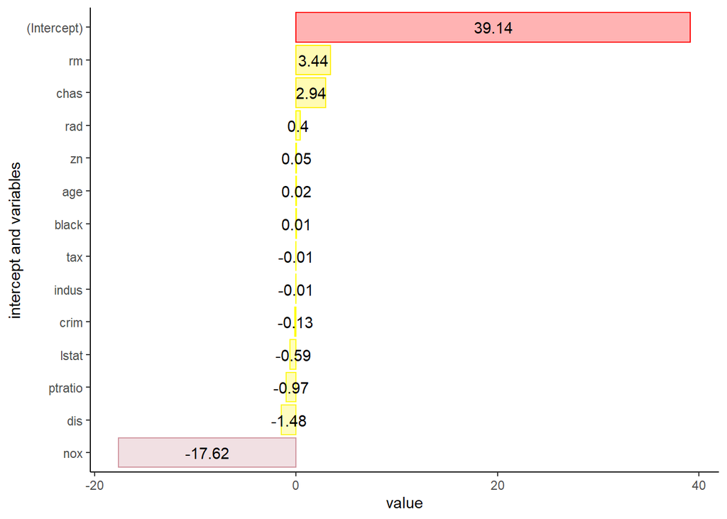

```r
fit_df %>%
  ggplot(aes(x=reorder(labels, fit_coefficients), y=fit_coefficients,
             fill=fit_coefficients, color=fit_coefficients))+
  geom_col()+
  geom_text(aes(y=0.5*fit_coefficients), label=paste0(fit_coefficients), color="black")+
  scale_fill_gradient2(low=alpha("blue", 0.3), mid=alpha("yellow", 0.3),
                       high=alpha("red", 0.3), midpoint=0, space="Lab")+
  scale_color_gradient2(low=alpha("blue", 1), mid=alpha("yellow", 1),
                        high=alpha("red", 1), midpoint=0, space="Lab")+
  guides(fill=FALSE, color=FALSE)+
  theme_classic()+
  labs(x="intercept and variables", y="value")+
  coord_flip()
```